# TPBilan

Vincent LE MEUR

2023-10-24

# Etude de cas basé sur un tableau individus-variables quantitatives

## Partie 1: Analyse en composantes principales normée

## Analyse des statistiques descriptives

```
##       SOLD            CHEQ             NDEC           MDEC            NBPR
##  Min.   :  231   Min.   :  24.0   Min.   : 0.0   Min.   :0.000   Min.   :0.00
##  1st Qu.: 3654   1st Qu.: 150.5   1st Qu.: 0.0   1st Qu.:0.000   1st Qu.:2.00
##  Median : 6016   Median : 394.0   Median : 1.0   Median :0.300   Median :3.00
##  Mean   :10870   Mean   : 569.9   Mean   : 1.8   Mean   :1.542   Mean   :3.04
##  3rd Qu.:11758   3rd Qu.: 960.0   3rd Qu.: 2.0   3rd Qu.:2.600   3rd Qu.:4.00
##  Max.   :85214   Max.   :2360.0   Max.   :12.0   Max.   :9.800   Max.   :6.00
##       NEMP            MEMP             VADO           DEPO
##  Min.   : 0.00   Min.   :  0.00   Min.   :-3.0   Min.   :  0.10
##  1st Qu.: 0.00   1st Qu.:  0.00   1st Qu.:-1.0   1st Qu.: 14.78
##  Median : 1.00   Median : 11.75   Median : 3.0   Median :112.55
##  Mean   : 2.04   Mean   : 58.07   Mean   : 3.7   Mean   :223.18
##  3rd Qu.: 3.00   3rd Qu.:110.08   3rd Qu.: 7.5   3rd Qu.:403.95
##  Max.   :30.00   Max.   :310.00   Max.   :15.0   Max.   :916.20
##       RETR             VARR            TAIL           AGEC
##  Min.   :  0.00   Min.   :-3.00   Min.   :1.00   Min.   :18.00
##  1st Qu.:  0.85   1st Qu.: 0.00   1st Qu.:2.00   1st Qu.:28.25
##  Median :  9.60   Median : 1.50   Median :2.50   Median :39.50
##  Mean   : 37.34   Mean   : 1.68   Mean   :2.78   Mean   :39.92
##  3rd Qu.: 79.33   3rd Qu.: 3.00   3rd Qu.:3.75   3rd Qu.:49.00
##  Max.   :257.70   Max.   : 9.00   Max.   :9.00   Max.   :78.00
```

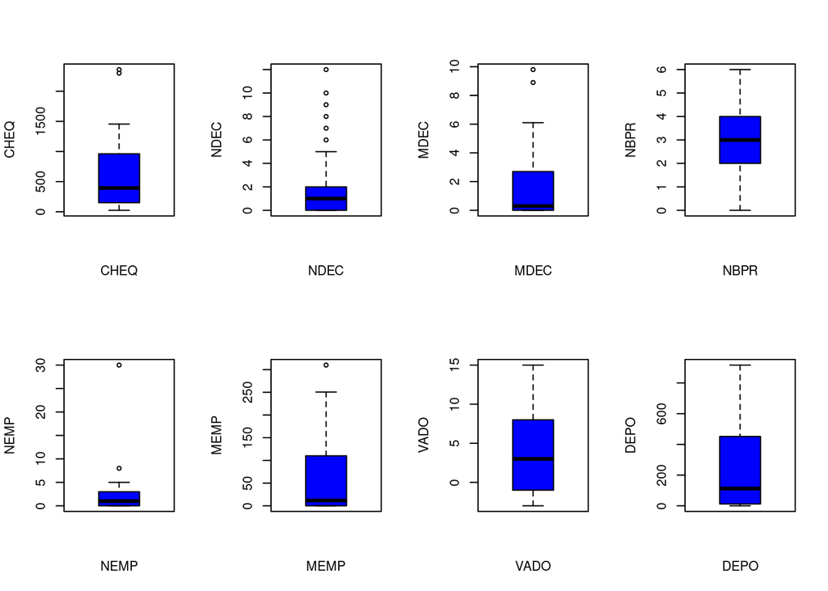

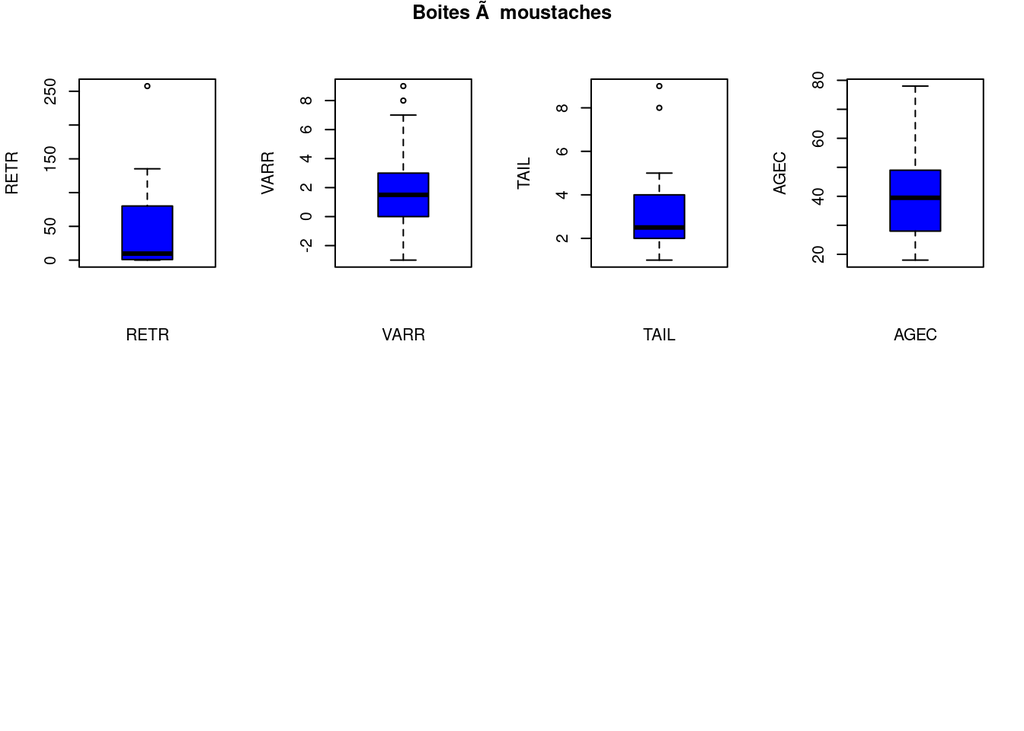

Grâce à toutes les variables de l’échantillon on remarque que la valeur maximale se trouve dans la variable SOLD et les valeurs minimales se trouvent dans les variables VARR et VADO

On observe une grande différence entre les moyennes des variables, on à pas le même ordre de grandeur entre elle. on ne peut donc pas les comparer. Par conséquent on va utiliser pour ce modèle une ACP normée.

## Matrice de corrélation

Matrice de correlation

|  | SOLD | CHEQ | NDEC | MDEC | NBPR | NEMP | MEMP | VADO | DEPO | RETR | VARR | TAIL | AGEC |
| --- | --- | --- | --- | --- | --- | --- | --- | --- | --- | --- | --- | --- | --- |
| SOLD | 1.0000000 | 0.4497754 | -0.2927783 | -0.2233598 | 0.0871820 | -0.1300827 | -0.1375483 | 0.6335509 | 0.7038842 | -0.1530521 | -0.2947168 | 0.2085113 | 0.2126053 |
| CHEQ | 0.4497754 | 1.0000000 | -0.2571892 | -0.2370706 | 0.2466580 | 0.1291306 | 0.0973539 | 0.2466259 | 0.3466217 | 0.0726055 | -0.0882506 | 0.3340581 | 0.1470314 |
| NDEC | -0.2927783 | -0.2571892 | 1.0000000 | 0.7448183 | -0.3458459 | -0.0751962 | -0.2182829 | -0.4085053 | -0.4254136 | -0.2153989 | 0.0655319 | -0.3291796 | -0.4534723 |
| MDEC | -0.2233598 | -0.2370706 | 0.7448183 | 1.0000000 | -0.1361459 | -0.0901456 | 0.0267691 | -0.2822819 | -0.3102525 | -0.0548966 | 0.1908410 | -0.2424492 | -0.2902184 |
| NBPR | 0.0871820 | 0.2466580 | -0.3458459 | -0.1361459 | 1.0000000 | 0.3927720 | 0.8050541 | 0.2169824 | 0.0666631 | 0.7072192 | 0.0630801 | 0.1706127 | 0.3536839 |
| NEMP | -0.1300827 | 0.1291306 | -0.0751962 | -0.0901456 | 0.3927720 | 1.0000000 | 0.4110844 | -0.0999020 | -0.1650721 | 0.3413466 | -0.0655896 | 0.0719954 | 0.1287648 |
| MEMP | -0.1375483 | 0.0973539 | -0.2182829 | 0.0267691 | 0.8050541 | 0.4110844 | 1.0000000 | -0.0830373 | -0.2141154 | 0.8463852 | 0.2533226 | 0.0289492 | 0.2104809 |
| VADO | 0.6335509 | 0.2466259 | -0.4085053 | -0.2822819 | 0.2169824 | -0.0999020 | -0.0830373 | 1.0000000 | 0.8902033 | -0.0872261 | -0.3475282 | 0.2356685 | 0.2496094 |
| DEPO | 0.7038842 | 0.3466217 | -0.4254136 | -0.3102525 | 0.0666631 | -0.1650721 | -0.2141154 | 0.8902033 | 1.0000000 | -0.2057204 | -0.3928707 | 0.2507958 | 0.2034960 |
| RETR | -0.1530521 | 0.0726055 | -0.2153989 | -0.0548966 | 0.7072192 | 0.3413466 | 0.8463852 | -0.0872261 | -0.2057204 | 1.0000000 | 0.1690283 | -0.0825485 | 0.1775697 |
| VARR | -0.2947168 | -0.0882506 | 0.0655319 | 0.1908410 | 0.0630801 | -0.0655896 | 0.2533226 | -0.3475282 | -0.3928707 | 0.1690283 | 1.0000000 | -0.1278668 | -0.1357429 |
| TAIL | 0.2085113 | 0.3340581 | -0.3291796 | -0.2424492 | 0.1706127 | 0.0719954 | 0.0289492 | 0.2356685 | 0.2507958 | -0.0825485 | -0.1278668 | 1.0000000 | 0.2952613 |
| AGEC | 0.2126053 | 0.1470314 | -0.4534723 | -0.2902184 | 0.3536839 | 0.1287648 | 0.2104809 | 0.2496094 | 0.2034960 | 0.1775697 | -0.1357429 | 0.2952613 | 1.0000000 |

Sur cette table, on peut observer la matrice des corrélations linéaires entre les variables actives de l’analyse. Cette matrice est carrée et symétrique et ne contient que des 1 sur la diagonale principale. Il s’agit de la corrélation de la variable avec elle-même.

On constate que plusieurs coefficients de corrélation linéaire sont supérieurs à 0,50:

VADO avec SOLD DEPO avec SOLD MDEC avec NDEC MEMP avec NBPR RETR avec NBPR RETR avec MEMP DEPO avec VADO

On pose les hypothèses:

Hypothèse nulle (H0) : Il n’y a pas de corrélation significative entre les deux variables (corrélation = 0).

Hypothèse (H1) : Il existe une corrélation significative entre les deux variables (corrélation ≠ 0).

Matrice des p-value

|  | SOLD | CHEQ | NDEC | MDEC | NBPR | NEMP | MEMP | VADO | DEPO | RETR | VARR | TAIL | AGEC |
| --- | --- | --- | --- | --- | --- | --- | --- | --- | --- | --- | --- | --- | --- |
| SOLD | NA | 0.0010492 | 0.0390797 | 0.1189452 | 0.5471570 | 0.3679113 | 0.3408175 | 0.0000008 | 0.0000000 | 0.2886281 | 0.0377419 | 0.1461870 | 0.1382530 |
| CHEQ | 0.0010492 | NA | 0.0713773 | 0.0973845 | 0.0842012 | 0.3714575 | 0.5012114 | 0.0842429 | 0.0136642 | 0.6163179 | 0.5422373 | 0.0177420 | 0.3082391 |
| NDEC | 0.0390797 | 0.0713773 | NA | 0.0000000 | 0.0138904 | 0.6037577 | 0.1277877 | 0.0032276 | 0.0020713 | 0.1330264 | 0.6511634 | 0.0195827 | 0.0009421 |
| MDEC | 0.1189452 | 0.0973845 | 0.0000000 | NA | 0.3458104 | 0.5335653 | 0.8535966 | 0.0470172 | 0.0283253 | 0.7049513 | 0.1843244 | 0.0898049 | 0.0409058 |
| NBPR | 0.5471570 | 0.0842012 | 0.0138904 | 0.3458104 | NA | 0.0047810 | 0.0000000 | 0.1301306 | 0.6455385 | 0.0000000 | 0.6634204 | 0.2361719 | 0.0117458 |
| NEMP | 0.3679113 | 0.3714575 | 0.6037577 | 0.5335653 | 0.0047810 | NA | 0.0030209 | 0.4900203 | 0.2519635 | 0.0152665 | 0.6508757 | 0.6192920 | 0.3728254 |
| MEMP | 0.3408175 | 0.5012114 | 0.1277877 | 0.8535966 | 0.0000000 | 0.0030209 | NA | 0.5664395 | 0.1354091 | 0.0000000 | 0.0758923 | 0.8418202 | 0.1423289 |
| VADO | 0.0000008 | 0.0842429 | 0.0032276 | 0.0470172 | 0.1301306 | 0.4900203 | 0.5664395 | NA | 0.0000000 | 0.5469535 | 0.0134039 | 0.0994394 | 0.0804377 |
| DEPO | 0.0000000 | 0.0136642 | 0.0020713 | 0.0283253 | 0.6455385 | 0.2519635 | 0.1354091 | 0.0000000 | NA | 0.1517859 | 0.0047695 | 0.0789627 | 0.1563603 |
| RETR | 0.2886281 | 0.6163179 | 0.1330264 | 0.7049513 | 0.0000000 | 0.0152665 | 0.0000000 | 0.5469535 | 0.1517859 | NA | 0.2406166 | 0.5687344 | 0.2173217 |
| VARR | 0.0377419 | 0.5422373 | 0.6511634 | 0.1843244 | 0.6634204 | 0.6508757 | 0.0758923 | 0.0134039 | 0.0047695 | 0.2406166 | NA | 0.3761965 | 0.3472532 |
| TAIL | 0.1461870 | 0.0177420 | 0.0195827 | 0.0898049 | 0.2361719 | 0.6192920 | 0.8418202 | 0.0994394 | 0.0789627 | 0.5687344 | 0.3761965 | NA | 0.0373730 |
| AGEC | 0.1382530 | 0.3082391 | 0.0009421 | 0.0409058 | 0.0117458 | 0.3728254 | 0.1423289 | 0.0804377 | 0.1563603 | 0.2173217 | 0.3472532 | 0.0373730 | NA |

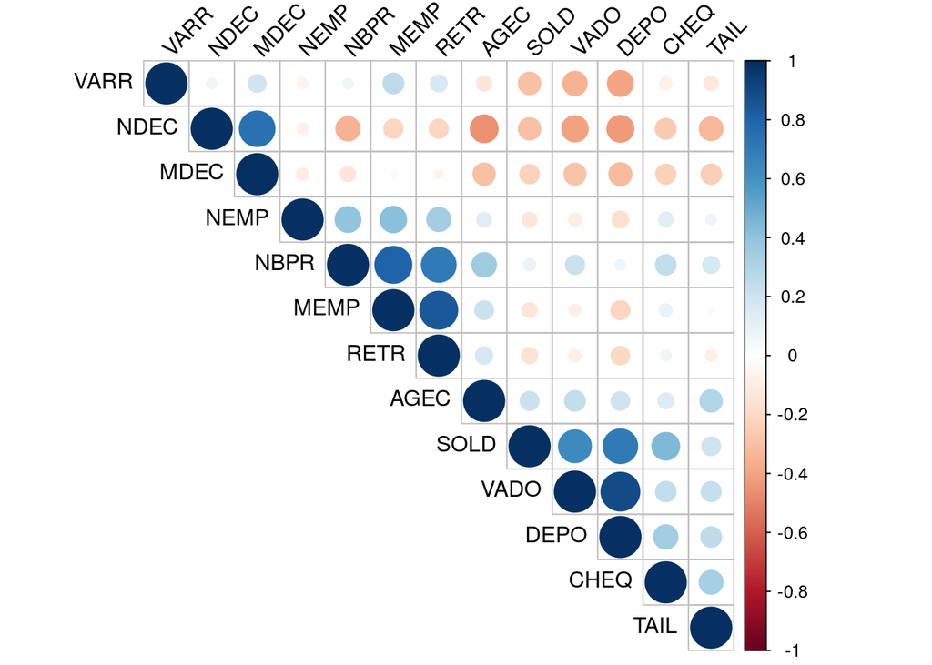

On peut observer que plusieurs variables sont corrélées positivement avec une p-value inférieur à 0.05 entre elles telles que NMEP et MEMP ou alors VADO et DEPO.

## ACP

```r
CB.pca = PCA(CB, scale.unit=TRUE,quanti.sup=12:13,graph=FALSE)
```

## Calcul inertir totale:

La formule est: la somme pondéré des carrés des distances des individus au centre de gravité

### Première manière

on fait la somme des valeurs propres:

```r
sum(CB.pca$eig[,1])
```

```
## [1] 11
```

### seconde manière

On effectue la somme des variances des variables étudiées

Ou on fait la trace de la matrice de corrélation

```r
sum(diag(matcor))-2
```

```
## [1] 11
```

## histogramme des valeurs propres

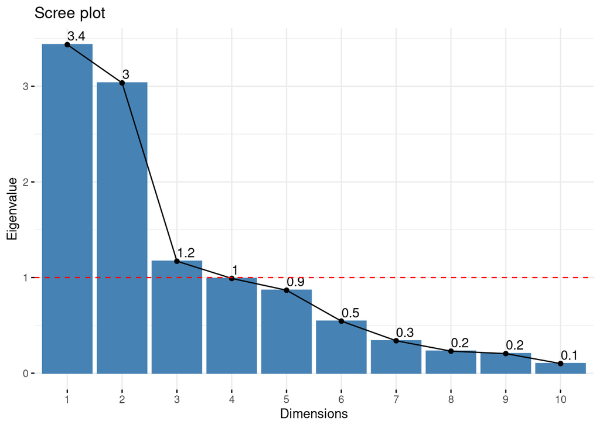

|  | eigenvalue | percentage of variance | cumulative percentage of variance |
| --- | --- | --- | --- |
| comp 1 | 3.4359695 | 31.2360864 | 31.23609 |
| comp 2 | 3.0357309 | 27.5975541 | 58.83364 |
| comp 3 | 1.1710517 | 10.6459241 | 69.47956 |
| comp 4 | 0.9909407 | 9.0085515 | 78.48812 |
| comp 5 | 0.8676484 | 7.8877123 | 86.37583 |
| comp 6 | 0.5443606 | 4.9487328 | 91.32456 |
| comp 7 | 0.3391620 | 3.0832911 | 94.40785 |
| comp 8 | 0.2305032 | 2.0954836 | 96.50334 |
| comp 9 | 0.2047862 | 1.8616931 | 98.36503 |
| comp 10 | 0.1004649 | 0.9133176 | 99.27835 |
| comp 11 | 0.0793819 | 0.7216534 | 100.00000 |